# zmPDSwR Chapter 3 Part I

coop711

2015년 9월 12일

# Data

## 자료 읽어들이기

```r
setwd("~/Dropbox/Works/Class/Data_Science/R.WD/zmPDSwR/")
custdata <- read.table("../../zmPDSwR/Custdata/custdata.tsv", header=TRUE, sep="\t", stringsAsFactors=TRUE)
```

## 기초 통계

- Missing values는 어디에 많이 등장하는가? 그 이유는 무엇이라고 생각되는가?

```r
summary(custdata)
```

```
##      custid        sex     is.employed         income
##  Min.   :   2068   F:440   Mode :logical   Min.   : -8700
##  1st Qu.: 345667   M:560   FALSE:73        1st Qu.: 14600
##  Median : 693403           TRUE :599       Median : 35000
##  Mean   : 698500           NA's :328       Mean   : 53505
##  3rd Qu.:1044606                           3rd Qu.: 67000
##  Max.   :1414286                           Max.   :615000
##
##              marital.stat health.ins
##  Divorced/Separated:155   Mode :logical
##  Married           :516   FALSE:159
##  Never Married     :233   TRUE :841
##  Widowed           : 96   NA's :0
##
##
##
##                        housing.type recent.move      num.vehicles
##  Homeowner free and clear    :157   Mode :logical   Min.   :0.000
##  Homeowner with mortgage/loan:412   FALSE:820       1st Qu.:1.000
##  Occupied with no rent       : 11   TRUE :124       Median :2.000
##  Rented                      :364   NA's :56        Mean   :1.916
##  NA's                        : 56                   3rd Qu.:2.000
##                                                     Max.   :6.000
##                                                     NA's   :56
##       age              state.of.res
##  Min.   :  0.0   California  :100
##  1st Qu.: 38.0   New York    : 71
##  Median : 50.0   Pennsylvania: 70
##  Mean   : 51.7   Texas       : 56
##  3rd Qu.: 64.0   Michigan    : 52
##  Max.   :146.7   Ohio        : 51
##                  (Other)     :600
```

- 타당치 않은 값들을 찾아본다면?

```r
summary(custdata$income)
```

```
##    Min. 1st Qu.  Median    Mean 3rd Qu.    Max.
##   -8700   14600   35000   53500   67000  615000
```

```r
summary(custdata$age)
```

```
##    Min. 1st Qu.  Median    Mean 3rd Qu.    Max.
##     0.0    38.0    50.0    51.7    64.0   146.7
```

## 자료 구조

- `factor` 의 `class`, `mode`, `typeof` 가 각각 어떻게 나타나는지 유의

```r
str(custdata)
```

```
## 'data.frame':    1000 obs. of  11 variables:
##  $ custid      : int  2068 2073 2848 5641 6369 8322 8521 12195 14989 15917 ...
##  $ sex         : Factor w/ 2 levels "F","M": 1 1 2 2 1 1 2 2 2 1 ...
##  $ is.employed : logi  NA NA TRUE TRUE TRUE TRUE ...
##  $ income      : int  11300 0 4500 20000 12000 180000 120000 40000 9400 24000 ...
##  $ marital.stat: Factor w/ 4 levels "Divorced/Separated",..: 2 2 3 3 3 3 3 2 2 1 ...
##  $ health.ins  : logi  TRUE TRUE FALSE FALSE TRUE TRUE ...
##  $ housing.type: Factor w/ 4 levels "Homeowner free and clear",..: 1 4 4 3 4 2 1 4 4 1 ...
##  $ recent.move : logi  FALSE TRUE TRUE FALSE TRUE FALSE ...
##  $ num.vehicles: int  2 3 3 0 1 1 1 3 2 1 ...
##  $ age         : num  49 40 22 22 31 40 39 48 44 70 ...
##  $ state.of.res: Factor w/ 50 levels "Alabama","Alaska",..: 22 9 10 31 9 32 12 22 13 33 ...
```

```r
sapply(custdata, class)
```

```
##       custid          sex  is.employed       income marital.stat
##    "integer"     "factor"    "logical"    "integer"     "factor"
##   health.ins housing.type  recent.move num.vehicles          age
##    "logical"     "factor"    "logical"    "integer"    "numeric"
## state.of.res
##     "factor"
```

```r
sapply(custdata, mode)
```

```
##       custid          sex  is.employed       income marital.stat
##    "numeric"    "numeric"    "logical"    "numeric"    "numeric"
##   health.ins housing.type  recent.move num.vehicles          age
##    "logical"    "numeric"    "logical"    "numeric"    "numeric"
## state.of.res
##    "numeric"
```

```r
sapply(custdata, typeof)
```

```
##       custid          sex  is.employed       income marital.stat
##    "integer"    "integer"    "logical"    "integer"    "integer"
##   health.ins housing.type  recent.move num.vehicles          age
##    "logical"    "integer"    "logical"    "integer"     "double"
## state.of.res
##    "integer"
```

## Visualization

- `with`를 쓰지 않고 `hist(custdata$age, prob=TRUE)`로 하면 어느 요소가 어떻게 달라지는가?

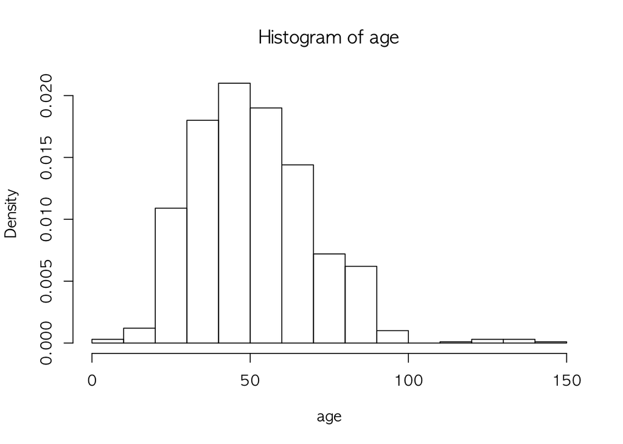

```r
with(custdata, hist(age, prob=TRUE))
```

- `density estimation`을 추가

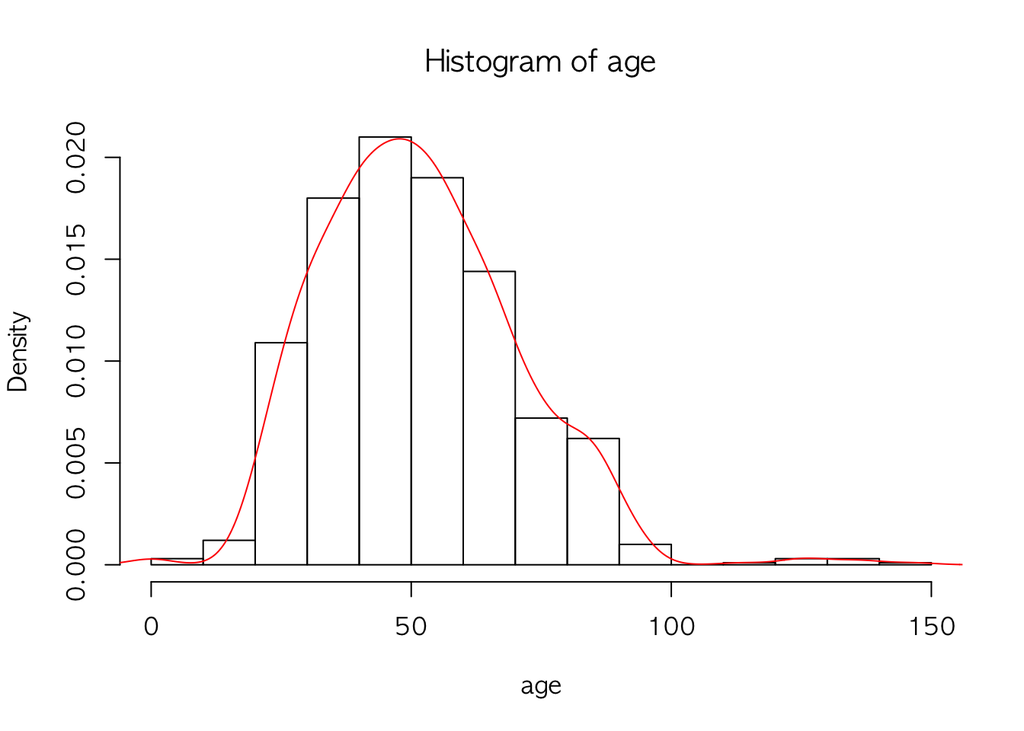

```r
with(custdata, hist(age, prob=TRUE))
with(custdata, lines(density(age), col="red"))
```

- `ggplot` 으로 표현하면,

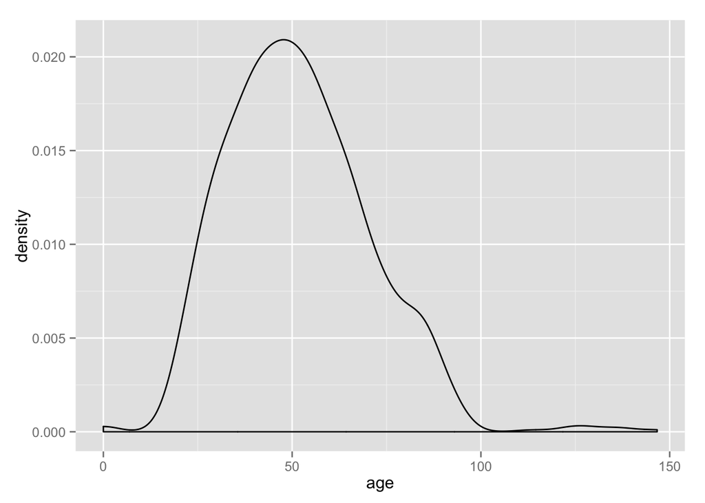

```r
library(ggplot2)
(g1 <- ggplot(custdata, aes(x=age)) + geom_density())
```

- 도표 안에 텍스트를 추가하려면, `annotate()` 사용

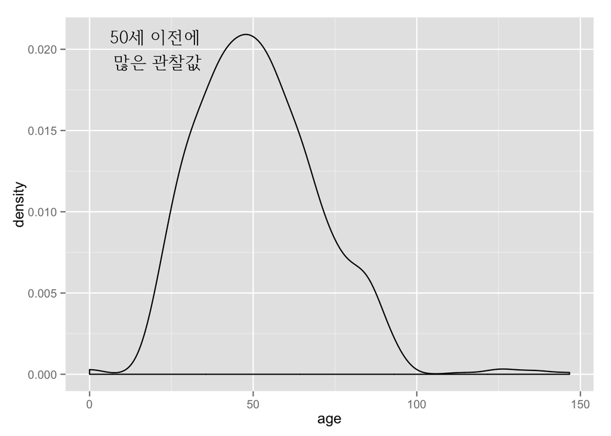

```r
(g2 <- g1 + annotate("text", x=20, y=0.02, label="50세 이전에\n 많은 관찰값", family="HCR Batang LVT"))
```

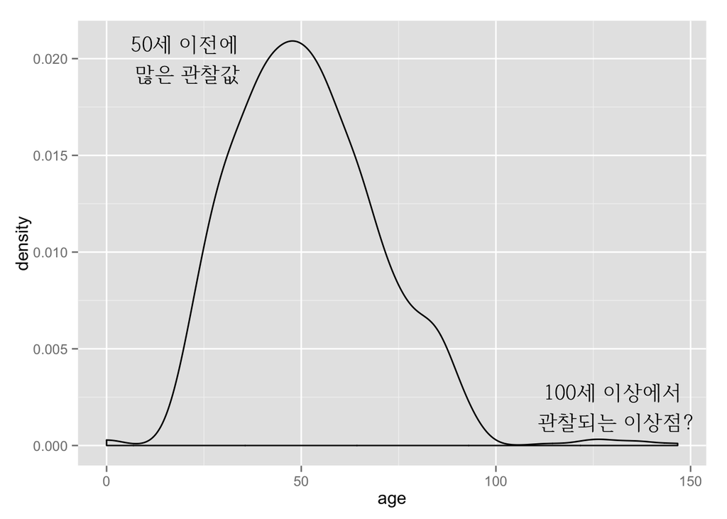

```r
(g3 <- g2 + annotate("text", x=130, y=0.002, label="100세 이상에서\n 관찰되는 이상점?", family="HCR Batang LVT"))
```

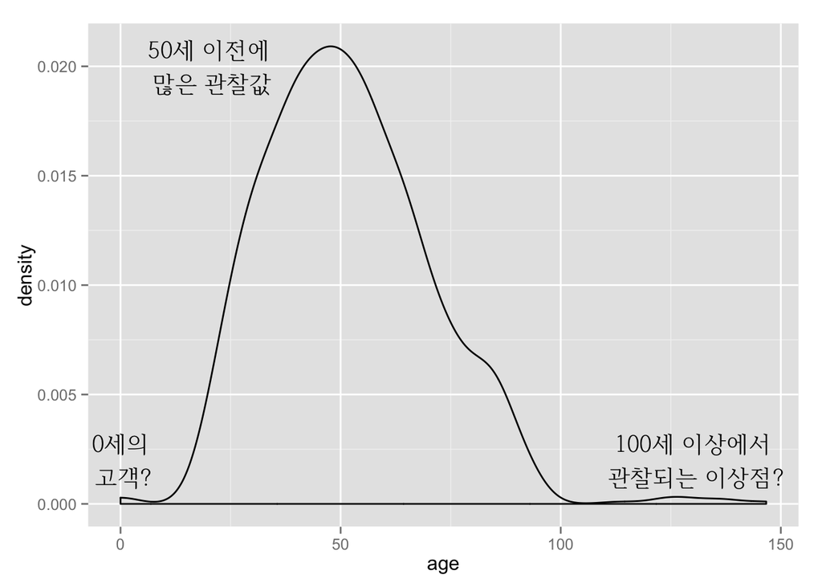

```r
(g4 <- g3 + annotate("text", x=0, y=0.002, label="0세의\n 고객?", family="HCR Batang LVT"))
```

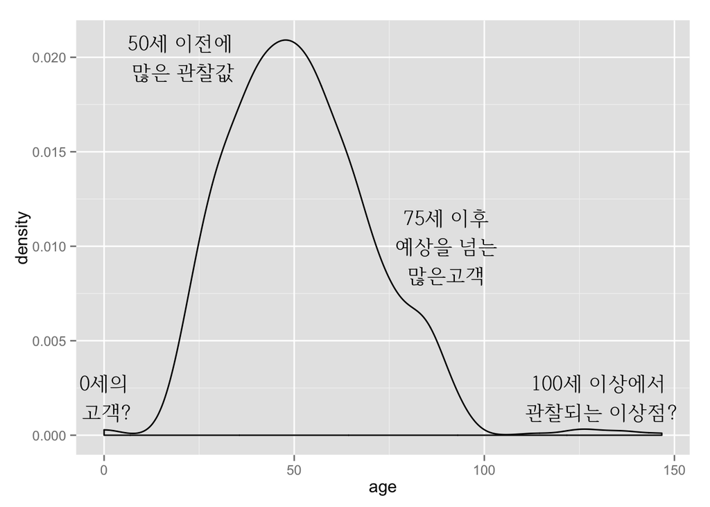

```r
(g5 <- g4 + annotate("text", x=90, y=0.01, label="75세 이후\n예상을 넘는\n많은고객", family="HCR Batang LVT"))
```

- 기초통계를 파악하는 데는 `summary()` 가 낫다는 기술에 대해서. 적어도 분위수에 관한 한 `ecdf`가 시각적으로 우수함.

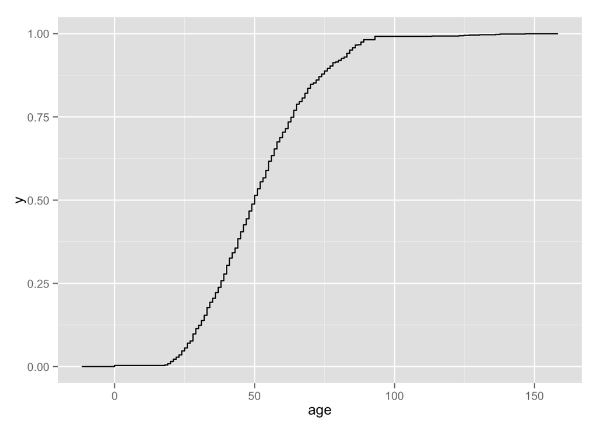

```r
(g.ecdf <- ggplot(custdata, aes(x=age)) + stat_ecdf())
```

- 게다가 도표 윗 부분은 바로 평균이라는 점을 기억해 두어야 할 것임. 좀 복잡해 보이지만, `geom_polygon()`을 이용하기 위해서는 다각형을 나타내는 좌표를 data frame으로 갖춰야 함.

```r
poly.x <- c(sort(custdata$age), sort(custdata$age)[1])
poly.y <- c((1:length(custdata$age))/length(custdata$age), 1)
poly.age <- data.frame(x=poly.x, y=poly.y)
```

- 제대로 갖추었는지 확인

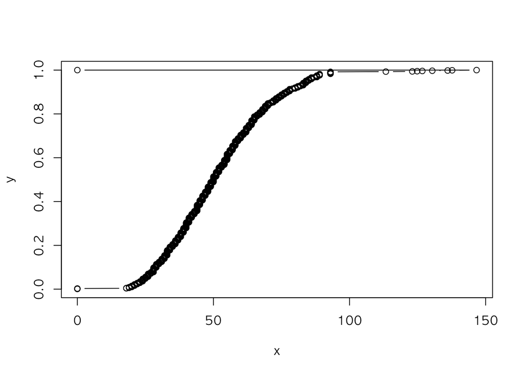

```r
plot(y ~ x, data=poly.age, type="b")
```

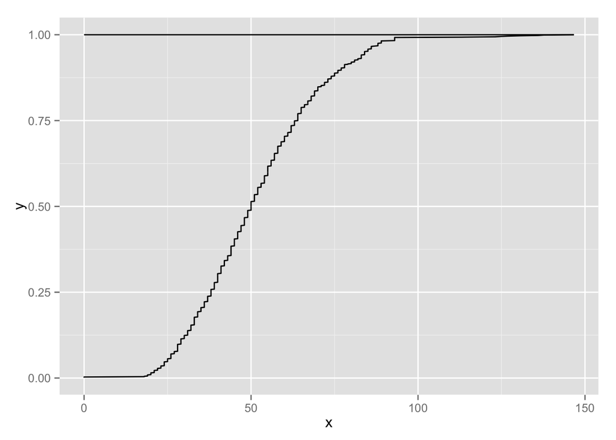

```r
ggplot(poly.age, aes(x=x, y=y)) + geom_path()
```

- `geom_polygon()` 에 `alpha`로 조정. 색은 `fill`로 설정.

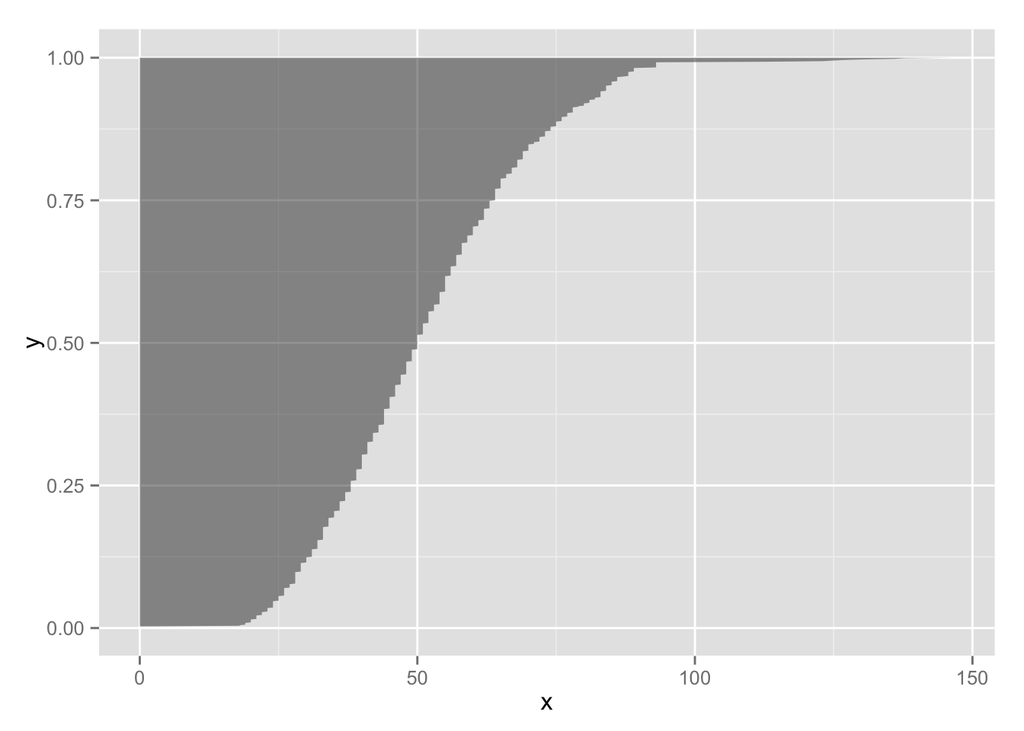

```r
(p <- ggplot(poly.age, aes(x=x, y=y)) + geom_polygon(alpha=0.5))
```

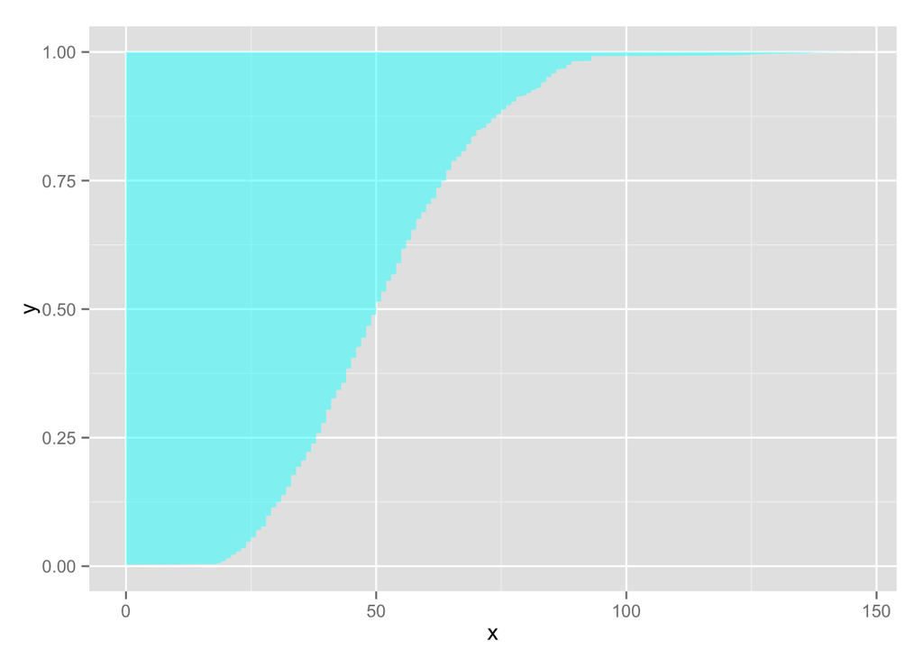

```r
(p1<- ggplot(poly.age, aes(x=x, y=y)) + geom_polygon(fill="cyan", alpha=0.5))
```

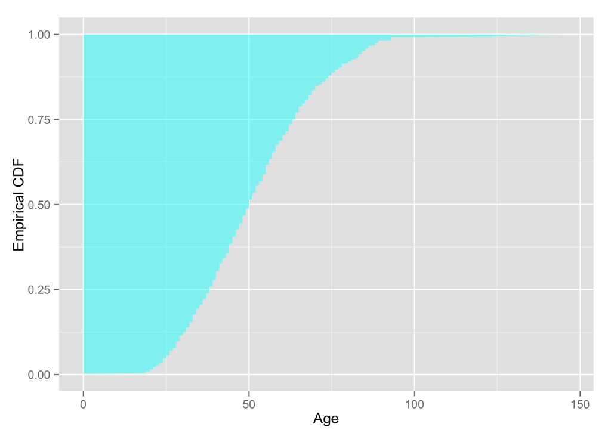

```r
(p2 <- p1 + xlab("Age") + ylab("Empirical CDF"))
```

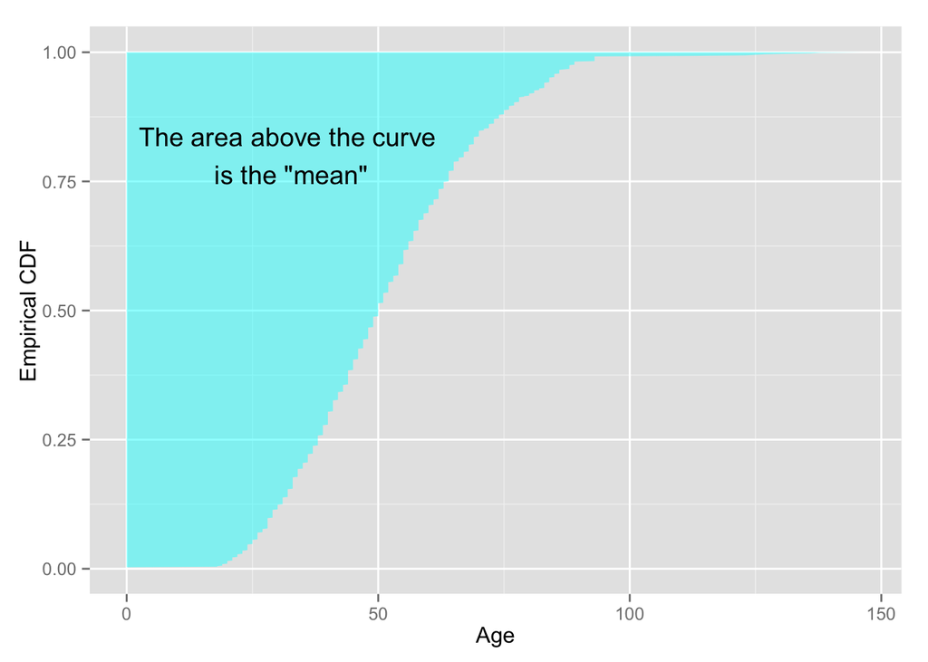

```r
(p3 <- p2 + annotate("text", x=32, y=0.8, label="The area above the curve\n is the \"mean\""))
```

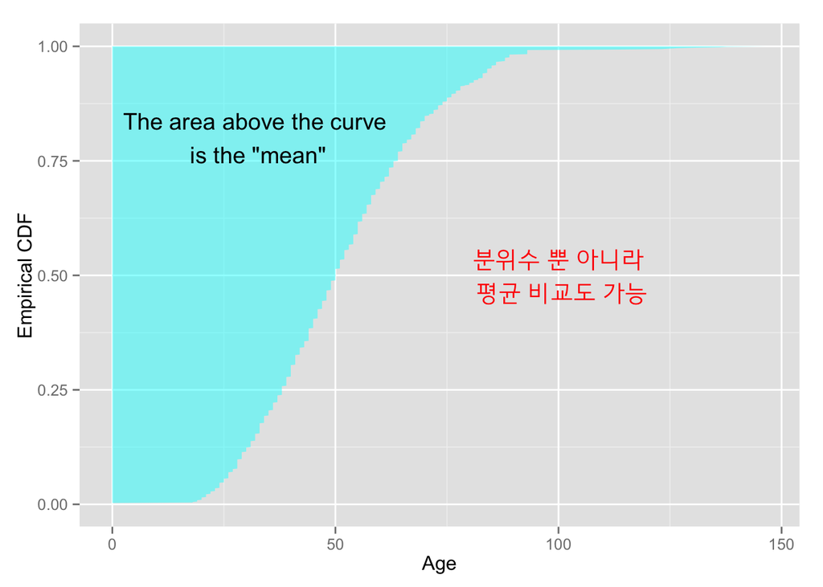

```r
(p4 <- p3 + annotate("text", x=100, y=0.5, label="분위수 뿐 아니라\n 평균 비교도 가능", family="HCR Dotum LVT", colour="red"))
```

- 히스토그램으로 요약하기. 각각의 차이가 어디서 비롯되는지 이해할 것.

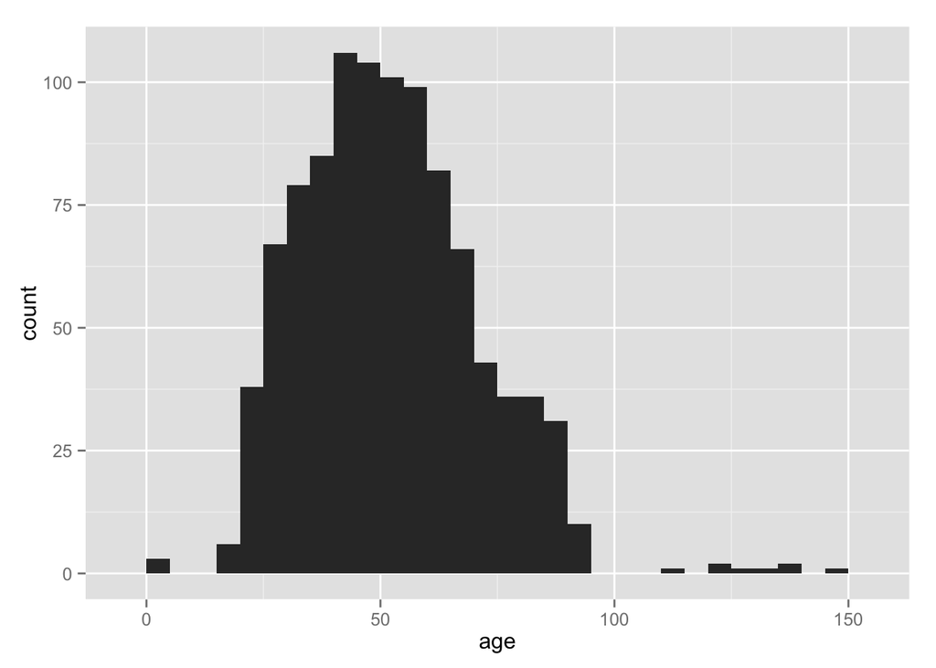

```r
ggplot(custdata, aes(x=age)) + geom_histogram(binwidth=5)
```

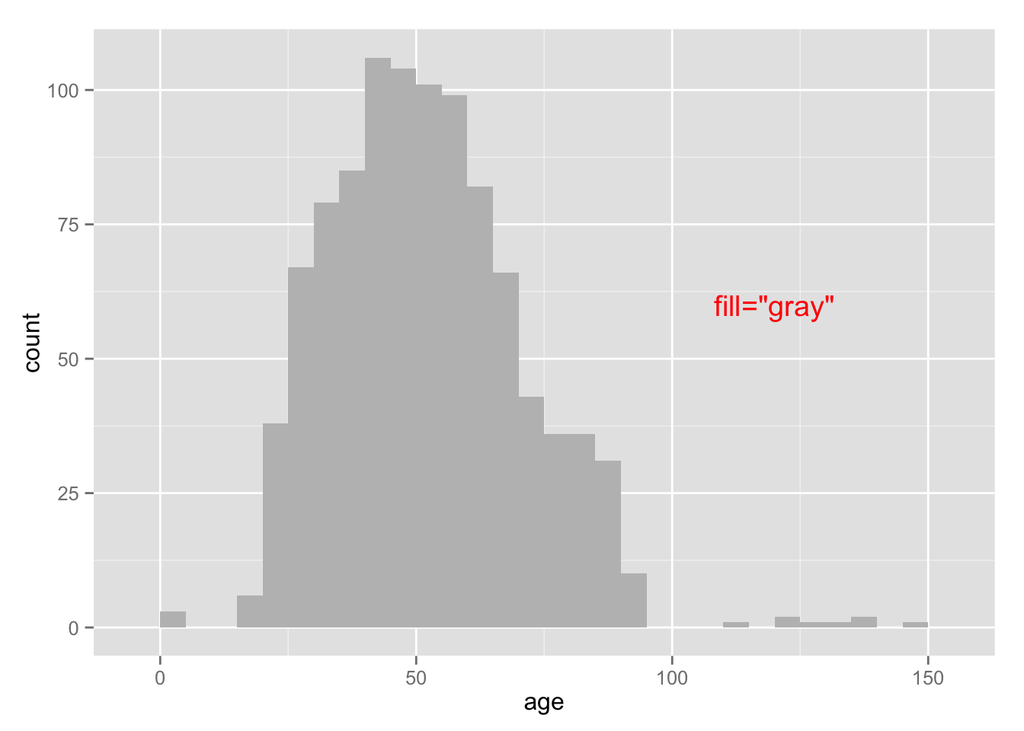

```r
ggplot(custdata, aes(x=age)) + geom_histogram(binwidth=5, fill="gray") +
  annotate("text", x=120, y=60, label="fill=\"gray\"", colour="red")
```

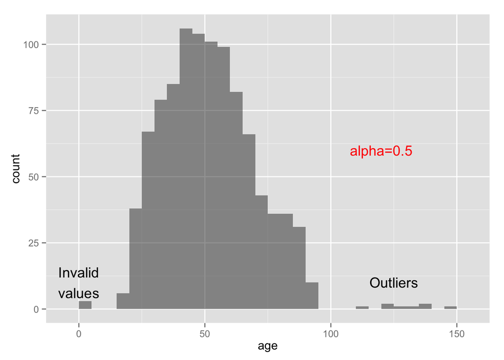

```r
ggplot(custdata, aes(x=age)) + geom_histogram(binwidth=5, alpha=0.5) +
  annotate("text", x=120, y=60, label="alpha=0.5", colour="red") +
  annotate("text", x=125, y=10, label="Outliers") +
  annotate("text", x=0, y=10, label="Invalid\nvalues")
```

- Density Plots

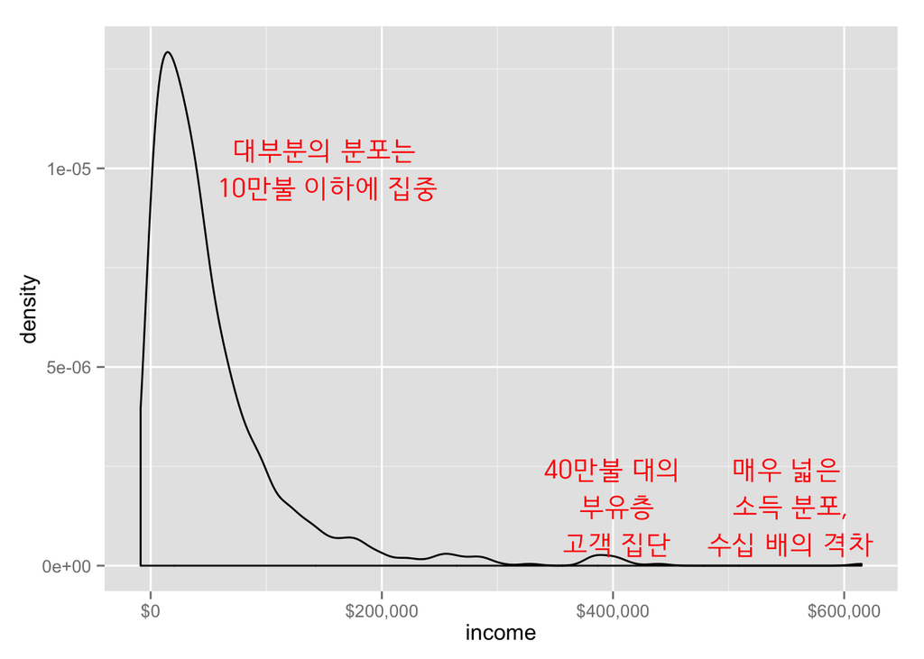

```r
library(scales)
ggplot(custdata) + geom_density(aes(x=income)) +
  scale_x_continuous(labels=dollar) +
  annotate("text", x=150000, y=0.00001, label="대부분의 분포는\n 10만불 이하에 집중", family="HCR Dotum LVT", colour="red") +
  annotate("text", x=400000, y=0.0000015, label="40만불 대의\n 부유층\n 고객 집단", family="HCR Dotum LVT", colour="red") +
  annotate("text", x=550000, y=0.0000015, label="매우 넓은\n 소득 분포,\n 수십 배의 격차", family="HCR Dotum LVT", colour="red")
```

- Density plots on log-scale. 왜 `warning=FALSE`를 켜 놓았는지 확인해 볼 것.